# Binge Worthy or Cancelled Show? Predicting Netflix Seasons

Dihella Ikapitte

5/6/25

# Introduction

Have you scrolled on Netflix, picked a random show that piqued your interest, and it became your favorite show? Have you ever wondered how long it might last? Will it continue to run for over 10 seasons or will Netflix pull the plug? Is it possible that we can predict how many seasons would a show have before it finishes or it cancels? In this data analysis project, I explored a Netflix themed dataset from Kaggle to answer an important question: Can I predict the amount of seasons in a show based on its duration and score? The reason why I wanted to delve into this dataset was because I’m interested and curious to uncover whether there are patterns to explain why some shows are short lived while other shows thrive for multiple seasons. I want to see what big decisions are made to determine a show’s future.

## Downloading packages

Let’s first load in our R packages and use read.csv from the tidyverse package so we can successfully use our dataset.

```r
library(tidyverse)
library(ggplot2)
library(dplyr)
library(caret)
library(rpart)
library(rpart.plot)
```

```r
shows_on_netflix <- read.csv("~/Desktop/archive (3)/Best Shows Netflix.csv")
```

## Introducing the Netflix dataset

[Netflix Dataset](https://www.kaggle.com/datasets/thedevastator/netflix-top-rated-movies-and-tv-shows-2020-2022)

Best.Shows.Netflix is a dataset from a a large data package from Kaggle called “Netflix Top Rated Movies and TV Shows.” The package is originally created by someone named Eduardo Gonzalez and uploaded on a website called Data World. The package was then uploaded by a user called The Devastator onto Kaggle and updated 2 years ago. This dataset contains the 246 shows that are scored 7.5 and higher in IMDb. From 1969 to 2022, many shows have been added to Netflix and have been reviewed as some of the top shows in television history.

# Exploring the dataset

I want to explore a little bit of the dataset before I start to predict. First, I want to see the dataset and see the what exactly is in it.

```r
shows_on_netflix
```

| index | TITLE | RELEASE_YEAR | SCORE | NUMBER_OF_VOTES | DURATION | NUMBER_OF_SEASONS | MAIN_GENRE | MAIN_PRODUCTION |
| --- | --- | --- | --- | --- | --- | --- | --- | --- |
| 0 | Breaking Bad | 2008 | 9.5 | 1727694 | 48 | 5 | drama | US |
| 1 | Avatar: The Last Airbender | 2005 | 9.3 | 297336 | 24 | 3 | scifi | US |
| 2 | Our Planet | 2019 | 9.3 | 41386 | 50 | 1 | documentary | GB |
| 3 | Kota Factory | 2019 | 9.3 | 66985 | 42 | 2 | drama | IN |
| 4 | The Last Dance | 2020 | 9.1 | 108321 | 50 | 1 | documentary | US |
| 5 | Arcane | 2021 | 9.1 | 175412 | 41 | 1 | action | US |
| 6 | Attack on Titan | 2013 | 9.0 | 325381 | 24 | 4 | scifi | JP |
| 7 | Hunter x Hunter | 2011 | 9.0 | 87857 | 23 | 3 | drama | JP |
| 8 | DEATH NOTE | 2006 | 9.0 | 302147 | 24 | 1 | scifi | JP |
| 9 | Seinfeld | 1989 | 8.9 | 302700 | 24 | 9 | comedy | US |

[output cut: 236 more lines]

Being able to see this entirety dataset, I can now start to answer my research question. So, let’s make 2 different graphs to have a summary of 2 categories: one with score and one with duration. Score and duration

```r
# First, I am selecting all of the scores from the dataset and giving it its own table
score_count <- shows_on_netflix |>
  count(SCORE) |>
  arrange(SCORE)
```

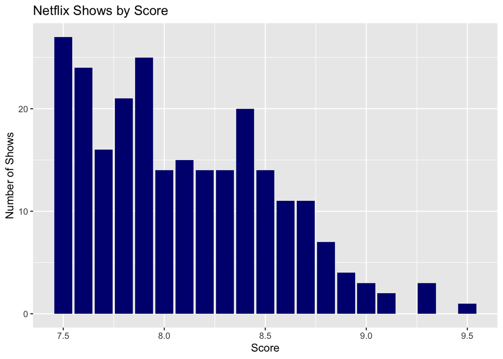

```r
# Next, I am creating a bar graph to see all of the scores of the dataset and which rating shows get
ggplot(score_count, aes(x = SCORE, y = n)) +
  geom_bar(stat = "identity", fill = "navy") +
  labs(
    title = "Netflix Shows by Score",
    x = "Score",
    y = "Number of Shows"
  )
```

```r
# Finding the mean of SCORE
mean(shows_on_netflix$SCORE)
```

```
## [1] 8.093496
```

## Observations

- The majority of shows are rated in between 7.5 and 8.5, showing that these shows are pretty average
- There is a steady decrease after 8.5, highlighting how uncommon highly rated shows are, based off of users of IMDb
- The distribution is right skewed

Next, let’s make see the duration of the shows.

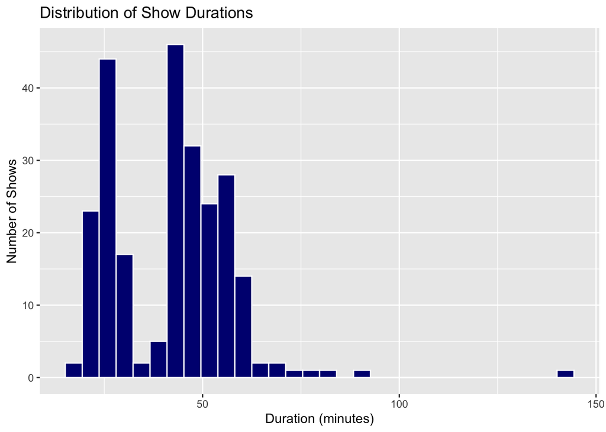

```r
ggplot(shows_on_netflix, aes(x = DURATION)) +
  geom_histogram(fill = "navy", color = "white") +
  labs(
    title = "Distribution of Show Durations",
    x = "Duration (minutes)",
    y = "Number of Shows"
  )
```

## Observations

- Most shows have a duration time between 20 minutes and 60 minutes
- The distribution of the graph is right skewed
- As the duration time of an episode increases, it becomes unlikely for a show to have a long duration

# Reseach Question

After exploring and reviewing the dataset, I can now use the knowledge I have to answer my question.

- Can I predict the amount of seasons in a show based on its duration and score?

## Step 1: Create a new dataset for the research question

First, let’s make another dataset, so I can use and to also not mess with the original dataset.

```r
shows_on_netflix_clean <- shows_on_netflix |>
  filter(!is.na(SCORE), !is.na(DURATION))
```

What I just did was to filter out any missing rows in score and duration, so it won’t mess up the predictions. Next, it’s time to split the data.

## Step 2: Splitting data

```r
set.seed(1818)
train_index <- createDataPartition(shows_on_netflix_clean$NUMBER_OF_SEASONS, p = 0.8, list = FALSE)
train_data <- shows_on_netflix_clean[train_index, ]
test_data <- shows_on_netflix_clean[-train_index, ]
```

First thing I did was:

- Set the seed to make sure that this can be reproduce with another person
- I created the train index to split the data with 80% going to training the dataset and 20% to testing the data

```r
tree_model <- rpart(NUMBER_OF_SEASONS ~ DURATION + SCORE, data = train_data)
```

- Here, I am using the rpart function build a decision tree model
- Next, I am saying to R, “predict the the number of seasons using duration and score
  - Duration and score are my explanatory variables
- And “data = train_data” is using my train_data for the tree

## Step 3: Create the decision tree

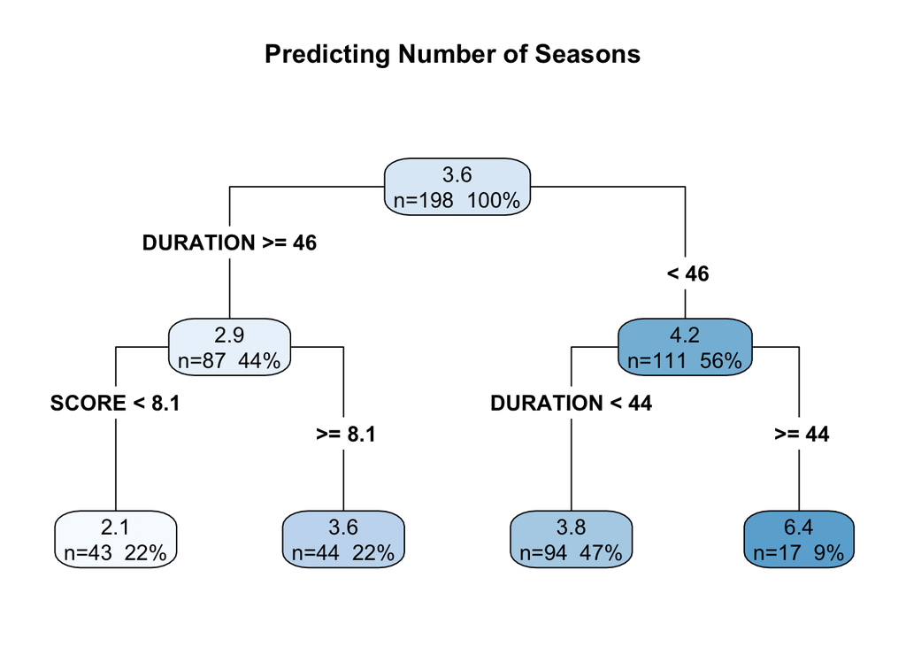

```r
rpart.plot(
  tree_model,
  type = 4,
  extra = 101,
  fallen.leaves = TRUE,
  main = "Predicting Number of Seasons"
  )
```

# Decision Tree Analysis

# Conclusion